# Boston Crime Data Analysis

This project is based on Boston Crime data between 2021-2023 downloaded from [this link](https://data.boston.gov/dataset/crime-incident-reports-august-2015-to-date-source-new-system)

Please answer the following eight questions and visualize each result. Please label each question clearly.

1. display number of crime by year, order by year
2. display number of crime by year and month in the format of year-month, order by year_month.
3. display average crime by month between 2021 and 2023. Visualize your result.
4. display average, min and max crime by month between 2021 and 2023
5. what time of the day has the highest crime
6. display number of crimes by weekday and the time of the day
7. display top 5 district based on number of crimes
8. for each top 5 districts, display top 5 types of crimes (offense_description) based on number of crimes

In addtion, there are many interesting questions you can explore using this dataset. Please come up at least five questions and develop Pyspark code to answer your questions and visualze the result. Please write a few paragraphs at the end to summarize your findings.

## Import dataset

```python
from pyspark.sql import SparkSession
import pyspark.sql.functions as F
from helper_functions import displayByGroup
import pandas as pd
import seaborn as sns
import matplotlib.pyplot as plt

# create a spark session
spark = SparkSession.builder.appName("Boston Crime Analysis")\
        .config("spark.port.maxRetries", "100")\
        .getOrCreate()

# confiture the log level (defaulty is WWARN)
spark.sparkContext.setLogLevel('ERROR')

# read the csv file, remove year with null value and remove current month (Septmber 2023)
crime = spark.read.csv("/opt/shared/boston_crime", header=True, inferSchema=True).filter(F.isnull(F.col('year'))==False)\
       .filter(F.date_format(F.col('occurred_on_date'), 'yyyy-MM')!='2023-09')

# change all columns to lower case

crime=crime.toDF(*[x.lower() for x in crime.columns])
```

```python
crime.printSchema()
```

```
root
 |-- incident_number: string (nullable = true)
 |-- offense_code: string (nullable = true)
 |-- offense_code_group: double (nullable = true)
 |-- offense_description: string (nullable = true)
 |-- district: string (nullable = true)
 |-- reporting_area: string (nullable = true)
 |-- shooting: integer (nullable = true)
 |-- occurred_on_date: timestamp (nullable = true)
 |-- year: integer (nullable = true)
 |-- month: integer (nullable = true)
 |-- day_of_week: string (nullable = true)
 |-- hour: integer (nullable = true)
 |-- ucr_part: string (nullable = true)
 |-- street: string (nullable = true)
 |-- lat: double (nullable = true)
 |-- long: double (nullable = true)
 |-- location: string (nullable = true)
```

```python
displayByGroup(crime, 5)
```

```
+---------------+------------+------------------+--------------------------------------------+--------+--------------+
|incident_number|offense_code|offense_code_group|offense_description                         |district|reporting_area|
+---------------+------------+------------------+--------------------------------------------+--------+--------------+
|232006462      |1107        |null              |FRAUD - IMPERSONATION                       |E13     |574           |
|232001473      |1102        |null              |FRAUD - FALSE PRETENSE / SCHEME             |D4      |              |
|232001482      |3820        |null              |M/V ACCIDENT - INVOLVING PEDESTRIAN - INJURY|C6      |186           |
|232001511      |3802        |null              |M/V ACCIDENT - PROPERTY DAMAGE              |C6      |              |
|232001476      |3831        |null              |M/V - LEAVING SCENE - PROPERTY DAMAGE       |B2      |239           |
+---------------+------------+------------------+--------------------------------------------+--------+--------------+
only showing top 5 rows

+--------+-------------------+----+-----+-----------+----+
|shooting|occurred_on_date   |year|month|day_of_week|hour|
+--------+-------------------+----+-----+-----------+----+
|0       |2022-12-31 16:00:00|2023|1    |Sunday     |0   |
|0       |2023-01-06 07:33:00|2023|1    |Friday     |15  |
|0       |2023-01-06 07:35:00|2023|1    |Friday     |15  |
|0       |2023-01-06 07:41:00|2023|1    |Friday     |15  |
|0       |2023-01-06 07:45:00|2023|1    |Friday     |15  |
+--------+-------------------+----+-----+-----------+----+
only showing top 5 rows

+--------+--------------------+------------------+------------------+----------------------------------------+
|ucr_part|street              |lat               |long              |location                                |
+--------+--------------------+------------------+------------------+----------------------------------------+
|null    |WASHINGTON ST       |42.30971815419562 |-71.10429497557632|(42.30971815419562, -71.10429497557632) |
|null    |HUNTINGTON AVE      |42.346130416133214|-71.08094490886702|(42.346130416133214, -71.08094490886702)|
|null    |MASSACHUSETTS AVENUE|null              |null              |null                                    |
|null    |VINTON ST           |42.329954642487486|-71.05369728684722|(42.329954642487486, -71.05369728684722)|
|null    |DUDLEY ST           |42.31735425056758 |-71.06583025569181|(42.31735425056758, -71.06583025569181) |
+--------+--------------------+------------------+------------------+----------------------------------------+
only showing top 5 rows
```

## Display top five offense

```python
crime.groupBy('offense_description').count().orderBy(F.desc('count')).limit(5).show()
```

```
+--------------------+-----+
| offense_description|count|
+--------------------+-----+
|  INVESTIGATE PERSON|20376|
|         SICK ASSIST|14762|
|M/V - LEAVING SCE...|12145|
|INVESTIGATE PROPERTY| 9375|
| TOWED MOTOR VEHICLE| 8518|
+--------------------+-----+
```

## Visualize the result

```python
# convert the result to pandas dataframe

pd_df=crime.groupBy('offense_description').count().orderBy(F.desc('count')).limit(5).toPandas()

pd_df.head()
```

|  | offense_description | count |
| --- | --- | --- |
| 0 | INVESTIGATE PERSON | 20376 |
| 1 | SICK ASSIST | 14762 |
| 2 | M/V - LEAVING SCENE - PROPERTY DAMAGE | 12145 |
| 3 | INVESTIGATE PROPERTY | 9375 |
| 4 | TOWED MOTOR VEHICLE | 8518 |

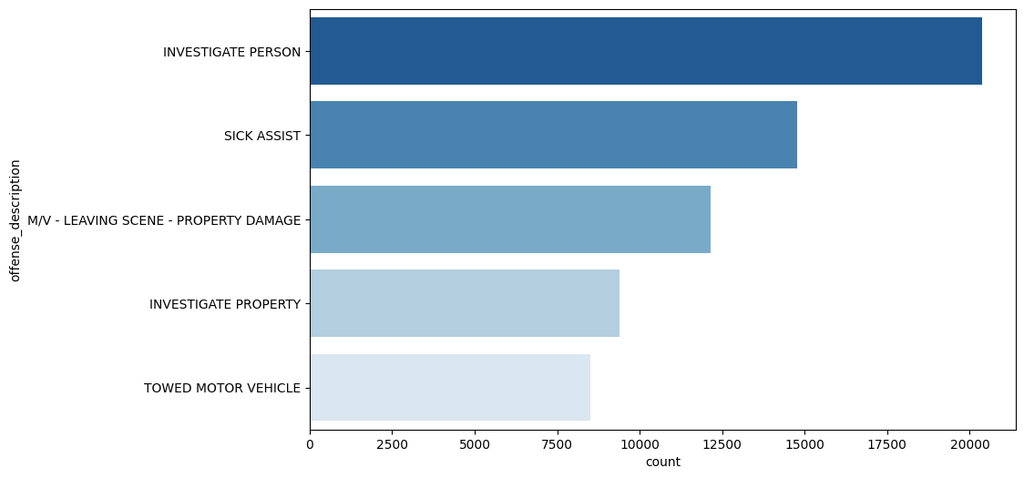

```python
# set the fiture size
plt.figure(figsize=(10,6))

sns.barplot(data=pd_df, y='offense_description',x="count", orient='h', palette='Blues_r')
```

## Put your solutions in the following section

## 1. Display the number of crime by year

```python
crime.groupBy('year').count().orderBy(F.desc('count')).show()
```

```
+----+-----+
|year|count|
+----+-----+
|2022|73852|
|2021|71721|
|2023|50982|
+----+-----+
```

```python
yr_df=crime.groupby('year').count().orderBy(F.desc('count')).toPandas()
yr_df.head()
```

|  | year | count |
| --- | --- | --- |
| 0 | 2022 | 73852 |
| 1 | 2021 | 71721 |
| 2 | 2023 | 50982 |

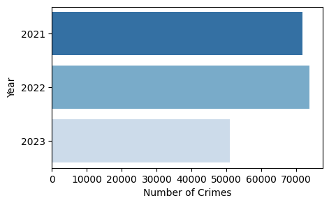

```python
plt.figure(figsize=(5,3))

by_yr = sns.barplot(data=yr_df, y='year',x="count", orient='h', palette='Blues_r')

by_yr.set_xlabel( "Number of Crimes")
by_yr.set_ylabel( "Year")
```

## 2. display number of crime by year and month in the format of year-month, order by year_month

```python
crime.select(F.col("occurred_on_date")).dtypes
```

```
[('occurred_on_date', 'timestamp')]
```

```python
crime1 = crime.withColumn('year_month', F.date_format(F.col('occurred_on_date'), 'yyyy-MM'))
```

```python
crime1.printSchema()
```

```
root
 |-- incident_number: string (nullable = true)
 |-- offense_code: string (nullable = true)
 |-- offense_code_group: double (nullable = true)
 |-- offense_description: string (nullable = true)
 |-- district: string (nullable = true)
 |-- reporting_area: string (nullable = true)
 |-- shooting: integer (nullable = true)
 |-- occurred_on_date: timestamp (nullable = true)
 |-- year: integer (nullable = true)
 |-- month: integer (nullable = true)
 |-- day_of_week: string (nullable = true)
 |-- hour: integer (nullable = true)
 |-- ucr_part: string (nullable = true)
 |-- street: string (nullable = true)
 |-- lat: double (nullable = true)
 |-- long: double (nullable = true)
 |-- location: string (nullable = true)
 |-- year_month: string (nullable = true)
```

```python
crime1.groupBy('year_month').count().orderBy(F.desc('year_month')).show(5)
```

```
+----------+-----+
|year_month|count|
+----------+-----+
|   2023-08| 6662|
|   2023-07| 6653|
|   2023-06| 6464|
|   2023-05| 6877|
|   2023-04| 6105|
+----------+-----+
only showing top 5 rows
```

```python
yr_mo = crime1.groupBy('year_month').count().orderBy(F.desc('year_month')).toPandas()
yr_mo.head(10)
```

|  | year_month | count |
| --- | --- | --- |
| 0 | 2023-08 | 6662 |
| 1 | 2023-07 | 6653 |
| 2 | 2023-06 | 6464 |
| 3 | 2023-05 | 6877 |
| 4 | 2023-04 | 6105 |
| 5 | 2023-03 | 6438 |
| 6 | 2023-02 | 5669 |
| 7 | 2023-01 | 6041 |
| 8 | 2022-12 | 5932 |
| 9 | 2022-11 | 5963 |

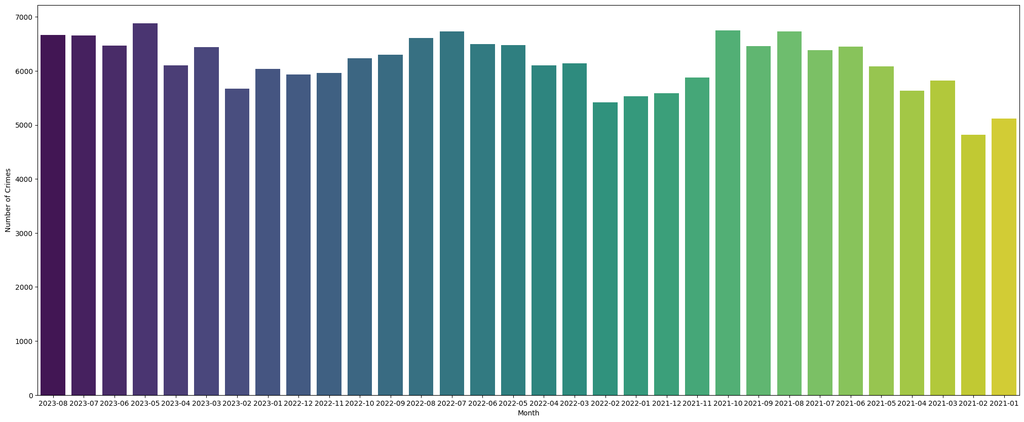

```python
plt.figure(figsize=(25,10))

yr_mo = sns.barplot(data=yr_mo, y='count',x="year_month", orient='v', palette='viridis')

yr_mo.set_xlabel( "Month")
yr_mo.set_ylabel( "Number of Crimes")
```

## 3.display average crime by month between 2021 and 2023. Visualize your result.

```python
crime4=crime1.groupBy("year",'month').agg(F.count('*').alias('count'))
crime4.show()
```

```
+----+-----+-----+
|year|month|count|
+----+-----+-----+
|2023|    3| 6429|
|2023|    2| 5684|
|2023|    4| 6117|
|2023|    5| 6882|
|2023|    1| 6048|
|2023|    8| 6652|
|2023|    7| 6683|
|2023|    6| 6452|
|2021|    5| 6087|
|2021|    3| 5821|
|2021|    2| 4822|
|2021|    1| 5115|
|2021|    4| 5631|
|2021|    8| 6730|
|2021|    6| 6450|
|2021|    7| 6387|
|2021|   10| 6753|
|2021|   11| 5879|
|2021|    9| 6463|
|2021|   12| 5583|
+----+-----+-----+
only showing top 20 rows
```

```python
averagecrime = crime4.groupBy('month').agg(F.avg('count').alias('averagecrimes'))
averagecrime.show()
```

```
+-----+-----------------+
|month|    averagecrimes|
+-----+-----------------+
|   12|           5721.0|
|    1|           5563.0|
|    6|6467.333333333333|
|    3|6128.666666666667|
|    5|           6481.0|
|    9|           4266.0|
|    4|5950.333333333333|
|    8|6664.666666666667|
|    7|6598.666666666667|
|   10|           6494.0|
|   11|           5921.0|
|    2|           5308.0|
+-----+-----------------+
```

```python
MoAvg = averagecrime.toPandas()
MoAvg.head()
```

|  | month | averagecrimes |
| --- | --- | --- |
| 0 | 12 | 5721.000000 |
| 1 | 1 | 5563.000000 |
| 2 | 6 | 6467.333333 |
| 3 | 3 | 6128.666667 |
| 4 | 5 | 6481.000000 |

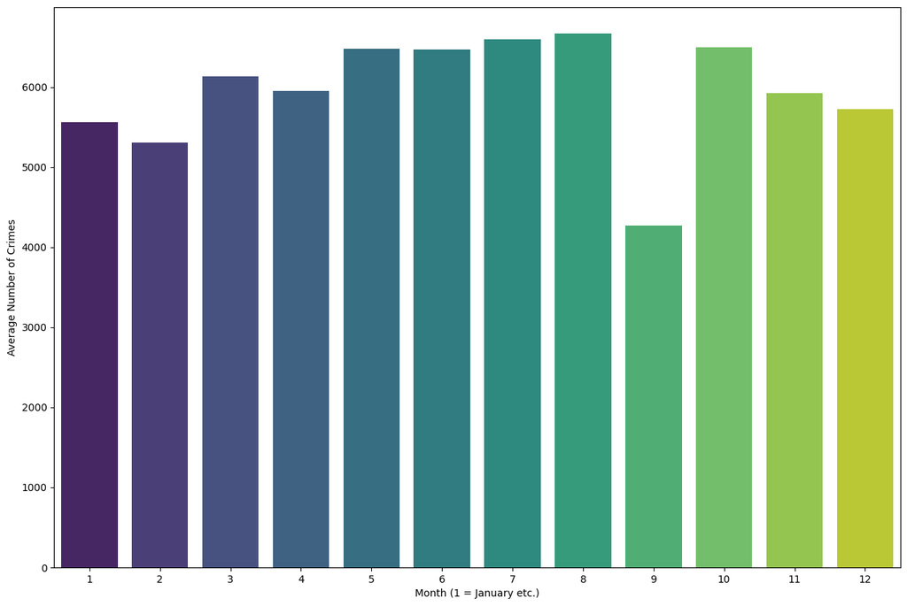

```python
plt.figure(figsize=(15,10))

MoAvg = sns.barplot(data=MoAvg, y='averagecrimes',x="month", orient='v', palette='viridis')

MoAvg.set_xlabel( "Month (1 = January etc.)")
MoAvg.set_ylabel( "Average Number of Crimes")
```

## 4.display average, min and max crime by month between 2021 and 2023

```python
crime4=crime1.groupBy("year",'month').agg(F.count('*').alias('count'))
crime4.show()
```

```
+----+-----+-----+
|year|month|count|
+----+-----+-----+
|2023|    3| 6429|
|2023|    2| 5684|
|2023|    4| 6117|
|2023|    5| 6882|
|2023|    1| 6048|
|2023|    8| 6652|
|2023|    7| 6683|
|2023|    6| 6452|
|2021|    5| 6087|
|2021|    3| 5821|
|2021|    2| 4822|
|2021|    1| 5115|
|2021|    4| 5631|
|2021|    8| 6730|
|2021|    6| 6450|
|2021|    7| 6387|
|2021|   10| 6753|
|2021|   11| 5879|
|2021|    9| 6463|
|2021|   12| 5583|
+----+-----+-----+
only showing top 20 rows
```

```python
mincrime = crime4.groupBy('month').agg(F.min('count').alias('mincrimes')).orderBy('month')
mincrime.show()
```

```
+-----+---------+
|month|mincrimes|
+-----+---------+
|    1|     5115|
|    2|     4822|
|    3|     5821|
|    4|     5631|
|    5|     6087|
|    6|     6450|
|    7|     6387|
|    8|     6612|
|    9|       35|
|   10|     6235|
|   11|     5879|
|   12|     5583|
+-----+---------+
```

```python
maxcrime = crime4.groupBy('month').agg(F.max('count').alias('maxcrimes')).orderBy('month')
maxcrime.show()
```

```
+-----+---------+
|month|maxcrimes|
+-----+---------+
|    1|     6048|
|    2|     5684|
|    3|     6429|
|    4|     6117|
|    5|     6882|
|    6|     6500|
|    7|     6726|
|    8|     6730|
|    9|     6463|
|   10|     6753|
|   11|     5963|
|   12|     5859|
+-----+---------+
```

```python
averagecrime = crime4.groupBy('month').agg(F.avg('count').alias('averagecrimes')).orderBy('month')
averagecrime.show()
```

```
+-----+-----------------+
|month|    averagecrimes|
+-----+-----------------+
|    1|           5563.0|
|    2|           5308.0|
|    3|6128.666666666667|
|    4|5950.333333333333|
|    5|           6481.0|
|    6|6467.333333333333|
|    7|6598.666666666667|
|    8|6664.666666666667|
|    9|           4266.0|
|   10|           6494.0|
|   11|           5921.0|
|   12|           5721.0|
+-----+-----------------+
```

```python
MoMin = mincrime.toPandas()
MoMin.head()
```

|  | month | mincrimes |
| --- | --- | --- |
| 0 | 1 | 5115 |
| 1 | 2 | 4822 |
| 2 | 3 | 5821 |
| 3 | 4 | 5631 |
| 4 | 5 | 6087 |

```python
MoMax = maxcrime.toPandas()
MoMax.head()
```

|  | month | maxcrimes |
| --- | --- | --- |
| 0 | 1 | 6048 |
| 1 | 2 | 5684 |
| 2 | 3 | 6429 |
| 3 | 4 | 6117 |
| 4 | 5 | 6882 |

```python
MoAvg = averagecrime.toPandas()
MoAvg.head()
```

|  | month | averagecrimes |
| --- | --- | --- |
| 0 | 1 | 5563.000000 |
| 1 | 2 | 5308.000000 |
| 2 | 3 | 6128.666667 |
| 3 | 4 | 5950.333333 |
| 4 | 5 | 6481.000000 |

```python
minmax = pd.merge(MoMin,MoMax, on='month',how='outer')
minmax.head()
```

|  | month | mincrimes | maxcrimes |
| --- | --- | --- | --- |
| 0 | 1 | 5115 | 6048 |
| 1 | 2 | 4822 | 5684 |
| 2 | 3 | 5821 | 6429 |
| 3 | 4 | 5631 | 6117 |
| 4 | 5 | 6087 | 6882 |

```python
combined = pd.merge(minmax,MoAvg, on='month',how='outer')
combined.head()
```

|  | month | mincrimes | maxcrimes | averagecrimes |
| --- | --- | --- | --- | --- |
| 0 | 1 | 5115 | 6048 | 5563.000000 |
| 1 | 2 | 4822 | 5684 | 5308.000000 |
| 2 | 3 | 5821 | 6429 | 6128.666667 |
| 3 | 4 | 5631 | 6117 | 5950.333333 |
| 4 | 5 | 6087 | 6882 | 6481.000000 |

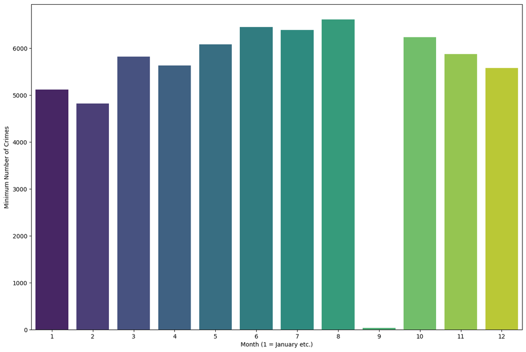

```python
plt.figure(figsize=(15,10))

combined1 = sns.barplot(data=combined, y='mincrimes',x="month", orient='v', palette='viridis')

combined1.set_xlabel( "Month (1 = January etc.)")
combined1.set_ylabel( "Minimum Number of Crimes")
```

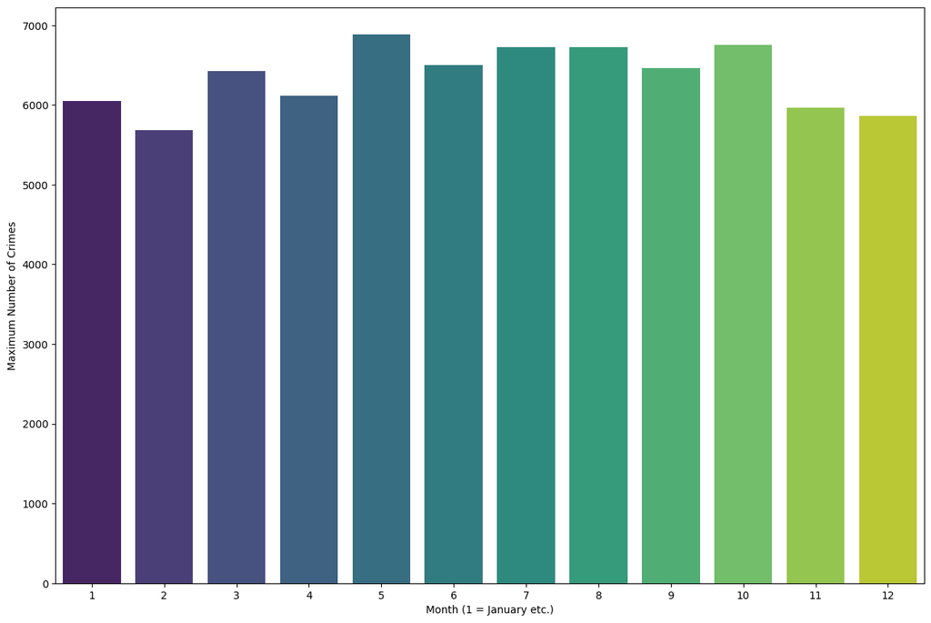

```python
plt.figure(figsize=(15,10))

combined1 = sns.barplot(data=combined, y='maxcrimes',x="month", orient='v', palette='viridis')

combined1.set_xlabel( "Month (1 = January etc.)")
combined1.set_ylabel( "Maximum Number of Crimes")
```

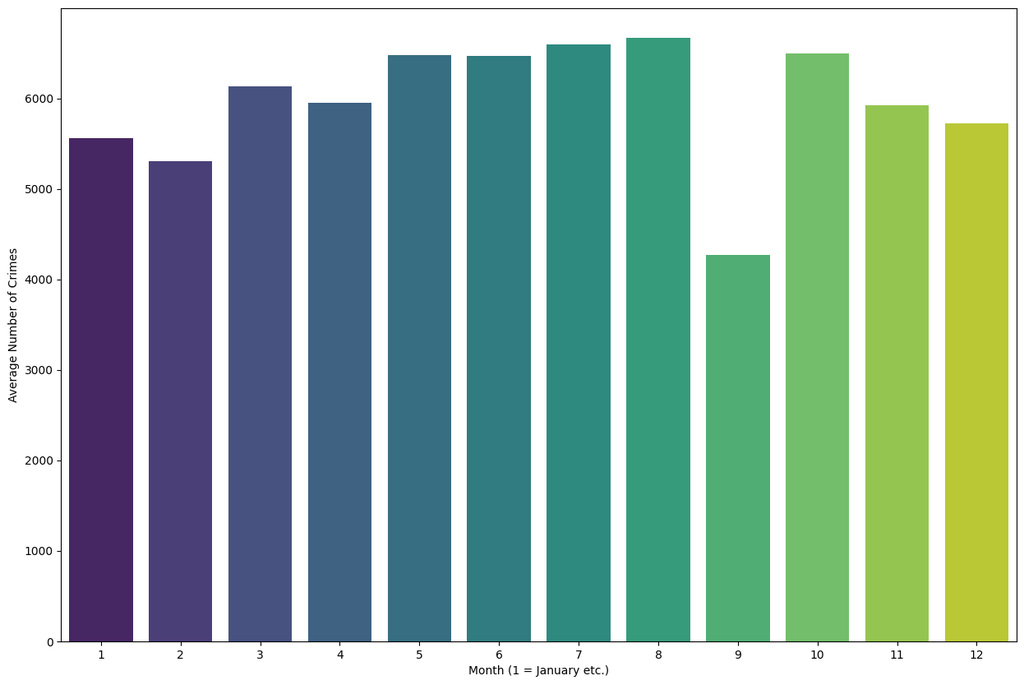

```python
plt.figure(figsize=(15,10))

combined1 = sns.barplot(data=combined, y='averagecrimes',x="month", orient='v', palette='viridis')

combined1.set_xlabel( "Month (1 = January etc.)")
combined1.set_ylabel( "Average Number of Crimes")
```

## 5.what time of day has the highest crime?

```python
crime.groupBy('hour').count().orderBy(F.desc('hour')).show(25)
```

```
+----+-----+
|hour|count|
+----+-----+
|  23| 5791|
|  22| 7411|
|  21| 8325|
|  20| 9198|
|  19|10056|
|  18|11427|
|  17|12337|
|  16|12156|
|  15|10135|
|  14|10638|
|  13|10350|
|  12|12037|
|  11|10347|
|  10|10136|
|   9| 8735|
|   8| 7913|
|   7| 5302|
|   6| 2930|
|   5| 2219|
|   4| 2121|
|   3| 2834|
|   2| 4377|
|   1| 5047|
|   0|14733|
+----+-----+
```

```python
hr_df=crime.groupby('hour').count().orderBy(F.desc('hour')).toPandas()
hr_df.head()
```

|  | hour | count |
| --- | --- | --- |
| 0 | 23 | 5791 |
| 1 | 22 | 7411 |
| 2 | 21 | 8325 |
| 3 | 20 | 9198 |
| 4 | 19 | 10056 |

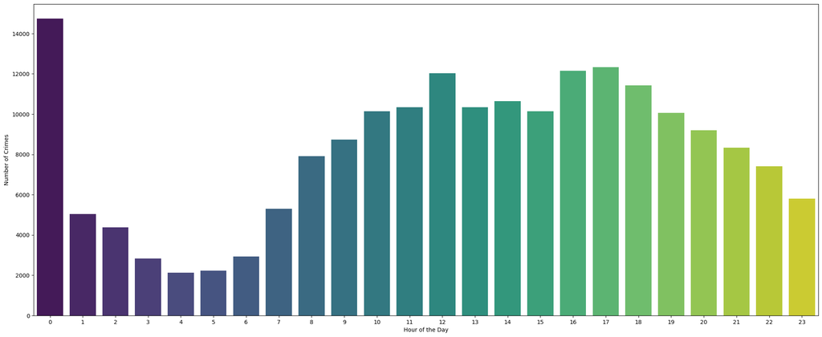

```python
plt.figure(figsize=(25,10))

by_yr = sns.barplot(data=hr_df, y='count',x="hour", orient='v', palette='viridis')

by_yr.set_xlabel( "Hour of the Day")
by_yr.set_ylabel( "Number of Crimes")
```

### The hour with the most crime is 0 or from 12am to 1am however high number of crimes consistentlty occur in the late morning to early and mid afternoon

```python
Monday=crime1.groupBy("day_of_week",'hour').agg(F.count('*').alias('count')).where(F.col("day_of_week") == "Monday")
Monday.show()
```

```
+-----------+----+-----+
|day_of_week|hour|count|
+-----------+----+-----+
|     Monday|   8| 1247|
|     Monday|   5|  318|
|     Monday|  15| 1494|
|     Monday|  20| 1311|
|     Monday|  17| 1905|
|     Monday|   9| 1374|
|     Monday|   1|  588|
|     Monday|   4|  295|
|     Monday|   7|  816|
|     Monday|   3|  331|
|     Monday|  22|  914|
|     Monday|  18| 1705|
|     Monday|  16| 1850|
|     Monday|  13| 1593|
|     Monday|  19| 1419|
|     Monday|  21| 1134|
|     Monday|  12| 1743|
|     Monday|   2|  579|
|     Monday|  10| 1435|
|     Monday|   0| 2200|
+-----------+----+-----+
only showing top 20 rows
```

```python
Monday=Monday.toPandas()
Monday.head()
```

|  | day_of_week | hour | count |
| --- | --- | --- | --- |
| 0 | Monday | 8 | 1247 |
| 1 | Monday | 5 | 318 |
| 2 | Monday | 15 | 1494 |
| 3 | Monday | 20 | 1311 |
| 4 | Monday | 17 | 1905 |

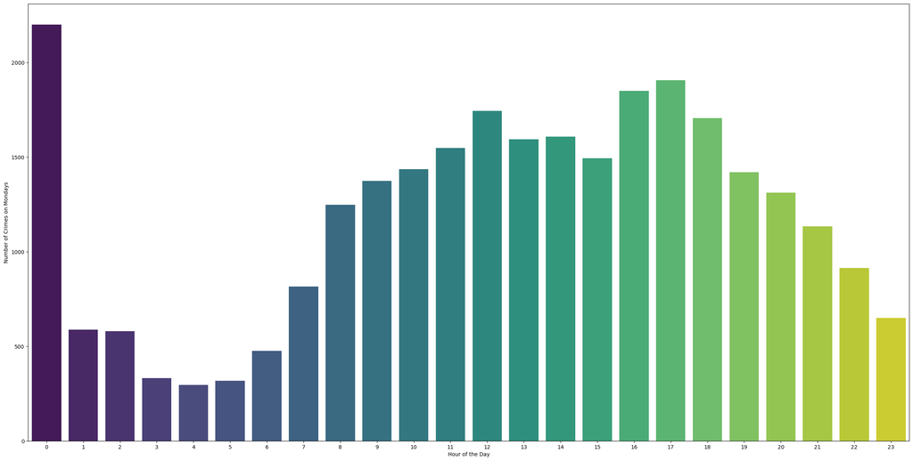

```python
plt.figure(figsize=(30,15))

Monday = sns.barplot(data=Monday, y='count',x="hour", orient='v', palette='viridis')

Monday.set_xlabel( "Hour of the Day")
Monday.set_ylabel( "Number of Crimes on Mondays")
```

```python
Tuesday=crime1.groupBy("day_of_week",'hour').agg(F.count('*').alias('count')).where(F.col("day_of_week") == "Tuesday")
Tuesday.show()
```

```
+-----------+----+-----+
|day_of_week|hour|count|
+-----------+----+-----+
|    Tuesday|  11| 1520|
|    Tuesday|   4|  223|
|    Tuesday|  14| 1533|
|    Tuesday|   9| 1329|
|    Tuesday|  13| 1456|
|    Tuesday|   7|  844|
|    Tuesday|   6|  435|
|    Tuesday|  19| 1497|
|    Tuesday|   2|  418|
|    Tuesday|  16| 1844|
|    Tuesday|  12| 1781|
|    Tuesday|   3|  301|
|    Tuesday|  10| 1510|
|    Tuesday|  22|  958|
|    Tuesday|  18| 1694|
|    Tuesday|  20| 1335|
|    Tuesday|  21| 1196|
|    Tuesday|   0| 1894|
|    Tuesday|  17| 1789|
|    Tuesday|   1|  548|
+-----------+----+-----+
only showing top 20 rows
```

```python
Tuesday=Tuesday.toPandas()
Tuesday.head()
```

|  | day_of_week | hour | count |
| --- | --- | --- | --- |
| 0 | Tuesday | 11 | 1520 |
| 1 | Tuesday | 4 | 223 |
| 2 | Tuesday | 14 | 1533 |
| 3 | Tuesday | 9 | 1329 |
| 4 | Tuesday | 13 | 1456 |

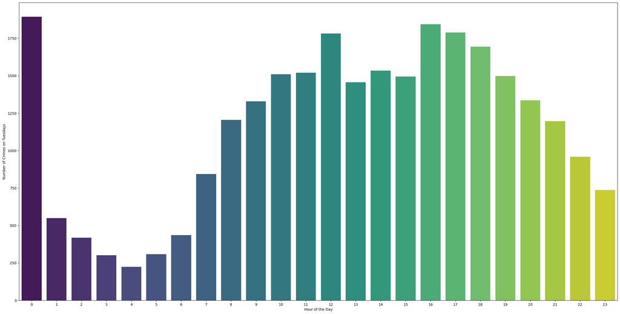

```python
plt.figure(figsize=(30,15))

Tuesday = sns.barplot(data=Tuesday, y='count',x="hour", orient='v', palette='viridis')

Tuesday.set_xlabel( "Hour of the Day")
Tuesday.set_ylabel( "Number of Crimes on Tuesdays")
```

```python
Wednesday=crime1.groupBy("day_of_week",'hour').agg(F.count('*').alias('count')).where(F.col("day_of_week") == "Wednesday")
Wednesday.show()
```

```
+-----------+----+-----+
|day_of_week|hour|count|
+-----------+----+-----+
|  Wednesday|   6|  452|
|  Wednesday|   7|  904|
|  Wednesday|   9| 1421|
|  Wednesday|   0| 2057|
|  Wednesday|   8| 1274|
|  Wednesday|  16| 1951|
|  Wednesday|  21| 1129|
|  Wednesday|  15| 1500|
|  Wednesday|  10| 1612|
|  Wednesday|  20| 1325|
|  Wednesday|  13| 1631|
|  Wednesday|   3|  319|
|  Wednesday|  18| 1690|
|  Wednesday|   1|  524|
|  Wednesday|   2|  442|
|  Wednesday|  14| 1588|
|  Wednesday|  23|  738|
|  Wednesday|  17| 1884|
|  Wednesday|  12| 1843|
|  Wednesday|  19| 1495|
+-----------+----+-----+
only showing top 20 rows
```

```python
Wednesday=Wednesday.toPandas()
Wednesday.head()
```

|  | day_of_week | hour | count |
| --- | --- | --- | --- |
| 0 | Wednesday | 6 | 452 |
| 1 | Wednesday | 7 | 904 |
| 2 | Wednesday | 9 | 1421 |
| 3 | Wednesday | 0 | 2057 |
| 4 | Wednesday | 8 | 1274 |

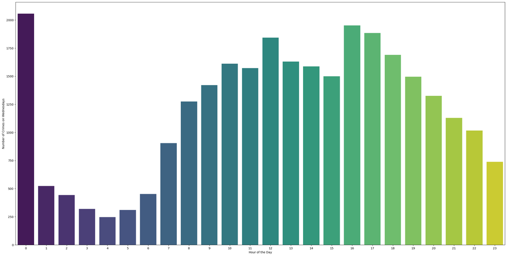

```python
plt.figure(figsize=(30,15))

Wednesday = sns.barplot(data=Wednesday, y='count',x="hour", orient='v', palette='viridis')

Wednesday.set_xlabel( "Hour of the Day")
Wednesday.set_ylabel( "Number of Crimes on Wednesdays")
```

```python
Thursday=crime1.groupBy("day_of_week",'hour').agg(F.count('*').alias('count')).where(F.col("day_of_week") == "Thursday")
Thursday.show()
```

```
+-----------+----+-----+
|day_of_week|hour|count|
+-----------+----+-----+
|   Thursday|   7|  806|
|   Thursday|  15| 1531|
|   Thursday|   8| 1230|
|   Thursday|  20| 1329|
|   Thursday|  12| 1893|
|   Thursday|  19| 1528|
|   Thursday|  17| 1797|
|   Thursday|   0| 2071|
|   Thursday|   2|  454|
|   Thursday|  13| 1612|
|   Thursday|  22| 1086|
|   Thursday|  16| 1841|
|   Thursday|   1|  552|
|   Thursday|   4|  259|
|   Thursday|  21| 1159|
|   Thursday|  23|  804|
|   Thursday|  11| 1589|
|   Thursday|   6|  432|
|   Thursday|  18| 1726|
|   Thursday|  14| 1676|
+-----------+----+-----+
only showing top 20 rows
```

```python
Thursday=Thursday.toPandas()
Thursday.head()
```

|  | day_of_week | hour | count |
| --- | --- | --- | --- |
| 0 | Thursday | 7 | 806 |
| 1 | Thursday | 15 | 1531 |
| 2 | Thursday | 8 | 1230 |
| 3 | Thursday | 20 | 1329 |
| 4 | Thursday | 12 | 1893 |

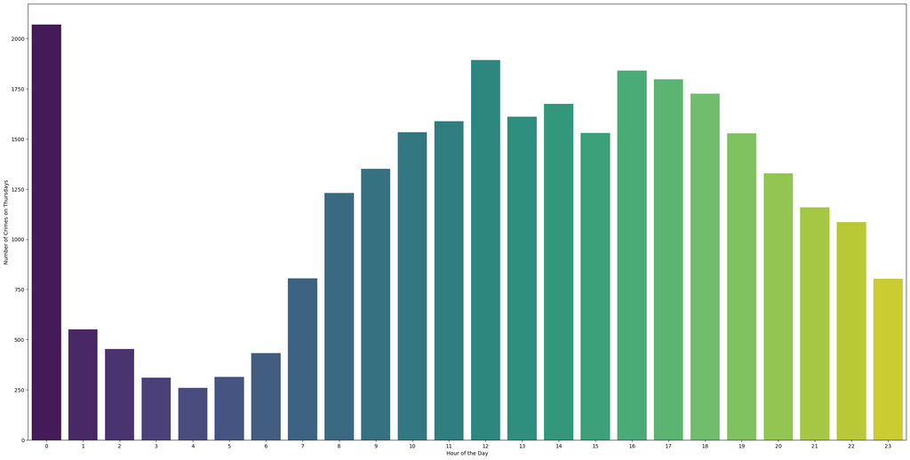

```python
plt.figure(figsize=(30,15))

Thursday = sns.barplot(data=Thursday, y='count',x="hour", orient='v', palette='viridis')

Thursday.set_xlabel( "Hour of the Day")
Thursday.set_ylabel( "Number of Crimes on Thursdays")
```

```python
Friday=crime1.groupBy("day_of_week",'hour').agg(F.count('*').alias('count')).where(F.col("day_of_week") == "Friday")
Friday.show()
```

```
+-----------+----+-----+
|day_of_week|hour|count|
+-----------+----+-----+
|     Friday|  18| 1730|
|     Friday|   6|  436|
|     Friday|  11| 1634|
|     Friday|  15| 1618|
|     Friday|  22| 1175|
|     Friday|   5|  320|
|     Friday|   0| 2129|
|     Friday|  16| 1858|
|     Friday|   4|  284|
|     Friday|   2|  554|
|     Friday|   9| 1335|
|     Friday|   3|  358|
|     Friday|   1|  684|
|     Friday|  19| 1506|
|     Friday|  21| 1295|
|     Friday|   8| 1225|
|     Friday|  13| 1588|
|     Friday|  17| 1929|
|     Friday|  12| 1852|
|     Friday|  14| 1565|
+-----------+----+-----+
only showing top 20 rows
```

```python
Friday=Friday.toPandas()
Friday.head()
```

|  | day_of_week | hour | count |
| --- | --- | --- | --- |
| 0 | Friday | 18 | 1730 |
| 1 | Friday | 6 | 436 |
| 2 | Friday | 11 | 1634 |
| 3 | Friday | 15 | 1618 |
| 4 | Friday | 22 | 1175 |

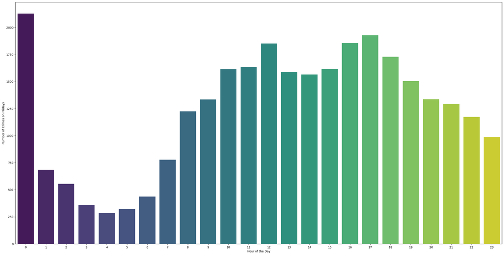

```python
plt.figure(figsize=(30,15))

Friday = sns.barplot(data=Friday, y='count',x="hour", orient='v', palette='viridis')

Friday.set_xlabel( "Hour of the Day")
Friday.set_ylabel( "Number of Crimes on Fridays")
```

```python
Saturday=crime1.groupBy("day_of_week",'hour').agg(F.count('*').alias('count')).where(F.col("day_of_week") == "Saturday")
Saturday.show()
```

```
+-----------+----+-----+
|day_of_week|hour|count|
+-----------+----+-----+
|   Saturday|  23| 1078|
|   Saturday|   6|  371|
|   Saturday|  10| 1378|
|   Saturday|   1| 1002|
|   Saturday|   9| 1070|
|   Saturday|   3|  555|
|   Saturday|  17| 1586|
|   Saturday|   4|  389|
|   Saturday|  19| 1371|
|   Saturday|   0| 2298|
|   Saturday|  11| 1361|
|   Saturday|  13| 1312|
|   Saturday|  20| 1377|
|   Saturday|  16| 1460|
|   Saturday|  12| 1589|
|   Saturday|   5|  320|
|   Saturday|  22| 1235|
|   Saturday|  15| 1277|
|   Saturday|   8|  965|
|   Saturday|  14| 1377|
+-----------+----+-----+
only showing top 20 rows
```

```python
Saturday=Saturday.toPandas()
Saturday.head()
```

|  | day_of_week | hour | count |
| --- | --- | --- | --- |
| 0 | Saturday | 23 | 1078 |
| 1 | Saturday | 6 | 371 |
| 2 | Saturday | 10 | 1378 |
| 3 | Saturday | 1 | 1002 |
| 4 | Saturday | 9 | 1070 |

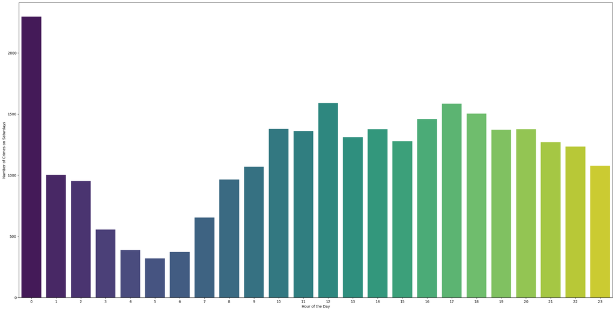

```python
plt.figure(figsize=(30,15))

Saturday = sns.barplot(data=Saturday, y='count',x="hour", orient='v', palette='viridis')

Saturday.set_xlabel( "Hour of the Day")
Saturday.set_ylabel( "Number of Crimes on Saturdays")
```

```python
Sunday=crime1.groupBy("day_of_week",'hour').agg(F.count('*').alias('count')).where(F.col("day_of_week") == "Sunday")
Sunday.show()
```

```
+-----------+----+-----+
|day_of_week|hour|count|
+-----------+----+-----+
|     Sunday|   1| 1149|
|     Sunday|  19| 1240|
|     Sunday|   2|  978|
|     Sunday|   5|  331|
|     Sunday|   8|  768|
|     Sunday|  15| 1221|
|     Sunday|   7|  501|
|     Sunday|  12| 1336|
|     Sunday|   6|  328|
|     Sunday|  16| 1352|
|     Sunday|  11| 1124|
|     Sunday|  23|  799|
|     Sunday|  22| 1027|
|     Sunday|   0| 2084|
|     Sunday|   4|  424|
|     Sunday|  17| 1447|
|     Sunday|  14| 1292|
|     Sunday|   9|  854|
|     Sunday|   3|  660|
|     Sunday|  20| 1185|
+-----------+----+-----+
only showing top 20 rows
```

```python
Sunday=Sunday.toPandas()
Sunday.head()
```

|  | day_of_week | hour | count |
| --- | --- | --- | --- |
| 0 | Sunday | 1 | 1149 |
| 1 | Sunday | 19 | 1240 |
| 2 | Sunday | 2 | 978 |
| 3 | Sunday | 5 | 331 |
| 4 | Sunday | 8 | 768 |

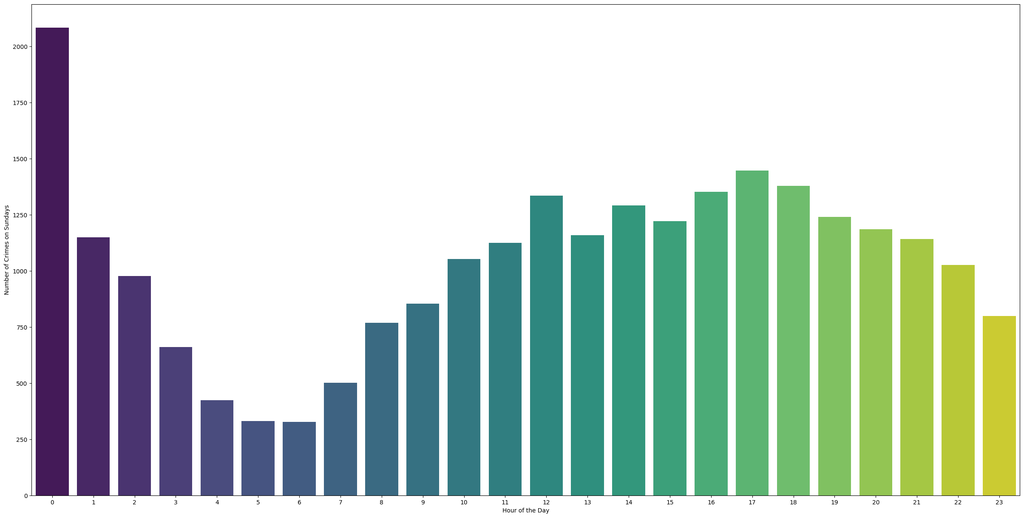

```python
plt.figure(figsize=(30,15))

Sunday = sns.barplot(data=Sunday, y='count',x="hour", orient='v', palette='viridis')

Sunday.set_xlabel( "Hour of the Day")
Sunday.set_ylabel( "Number of Crimes on Sundays")
```

## 7.display top 5 district based on number of crimes

```python
crime1.groupBy('district').count().dropna().orderBy(F.desc('count')).limit(5).show()
```

```
+--------+-----+
|district|count|
+--------+-----+
|      B2|26651|
|      D4|25513|
|     C11|24265|
|      A1|22974|
|      B3|20030|
+--------+-----+
```

```python
dist= crime1.groupBy('district').count().dropna().orderBy(F.desc('count')).limit(5).toPandas()
```

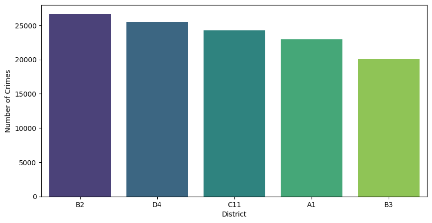

```python
plt.figure(figsize=(10,5))

dist = sns.barplot(data=dist, y='count',x="district", orient='v', palette='viridis')

dist.set_xlabel( "District")
dist.set_ylabel( "Number of Crimes")
```

## 8. for each top 5 districts, display top 5 types of crimes (offense_description) based on number of crimes

```python
tfB2=crime1.groupBy("district",'offense_description').agg(F.count('*').alias('count')).where(F.col("district") == "B2").orderBy(F.desc('count')).limit(5)
tfB2.show()
```

```
+--------+--------------------+-----+
|district| offense_description|count|
+--------+--------------------+-----+
|      B2|  INVESTIGATE PERSON| 2762|
|      B2|         SICK ASSIST| 2060|
|      B2|M/V - LEAVING SCE...| 1800|
|      B2|INVESTIGATE PROPERTY| 1441|
|      B2|           VANDALISM| 1191|
+--------+--------------------+-----+
```

```python
tfB2=tfB2.toPandas()
tfB2.head()
```

|  | district | offense_description | count |
| --- | --- | --- | --- |
| 0 | B2 | INVESTIGATE PERSON | 2762 |
| 1 | B2 | SICK ASSIST | 2060 |
| 2 | B2 | M/V - LEAVING SCENE - PROPERTY DAMAGE | 1800 |
| 3 | B2 | INVESTIGATE PROPERTY | 1441 |
| 4 | B2 | VANDALISM | 1191 |

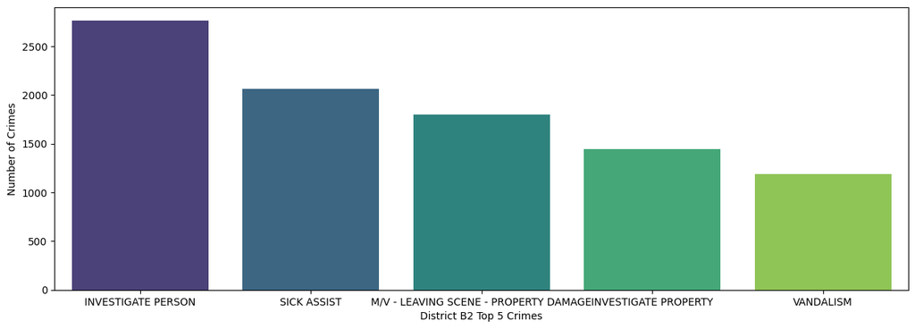

```python
plt.figure(figsize=(15,5))

dist = sns.barplot(data=tfB2, y='count',x="offense_description", orient='v', palette='viridis')

dist.set_xlabel( "District B2 Top 5 Crimes")
dist.set_ylabel( "Number of Crimes")
```

```python
tfD4=crime1.groupBy("district",'offense_description').agg(F.count('*').alias('count')).where(F.col("district") == "D4").orderBy(F.desc('count')).limit(5)
tfD4.show()
```

```
+--------+--------------------+-----+
|district| offense_description|count|
+--------+--------------------+-----+
|      D4|  INVESTIGATE PERSON| 2361|
|      D4| LARCENY SHOPLIFTING| 2279|
|      D4|         SICK ASSIST| 1882|
|      D4|INVESTIGATE PROPERTY| 1132|
|      D4|    ASSAULT - SIMPLE| 1131|
+--------+--------------------+-----+
```

```python
tfD4=tfD4.toPandas()
tfD4.head()
```

|  | district | offense_description | count |
| --- | --- | --- | --- |
| 0 | D4 | INVESTIGATE PERSON | 2361 |
| 1 | D4 | LARCENY SHOPLIFTING | 2279 |
| 2 | D4 | SICK ASSIST | 1882 |
| 3 | D4 | INVESTIGATE PROPERTY | 1132 |
| 4 | D4 | ASSAULT - SIMPLE | 1131 |

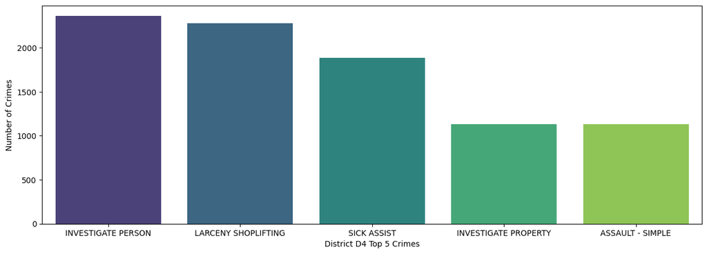

```python
plt.figure(figsize=(15,5))

dist = sns.barplot(data=tfD4, y='count',x="offense_description", orient='v', palette='viridis')

dist.set_xlabel( "District D4 Top 5 Crimes")
dist.set_ylabel( "Number of Crimes")
```

```python
tfC11=crime1.groupBy("district",'offense_description').agg(F.count('*').alias('count')).where(F.col("district") == "C11").orderBy(F.desc('count')).limit(5)
tfC11.show()
```

```
+--------+--------------------+-----+
|district| offense_description|count|
+--------+--------------------+-----+
|     C11|M/V - LEAVING SCE...| 2170|
|     C11|  INVESTIGATE PERSON| 2097|
|     C11|         SICK ASSIST| 1667|
|     C11|INVESTIGATE PROPERTY| 1297|
|     C11|           VANDALISM| 1151|
+--------+--------------------+-----+
```

```python
tfC11=tfC11.toPandas()
tfC11.head()
```

|  | district | offense_description | count |
| --- | --- | --- | --- |
| 0 | C11 | M/V - LEAVING SCENE - PROPERTY DAMAGE | 2170 |
| 1 | C11 | INVESTIGATE PERSON | 2097 |
| 2 | C11 | SICK ASSIST | 1667 |
| 3 | C11 | INVESTIGATE PROPERTY | 1297 |
| 4 | C11 | VANDALISM | 1151 |

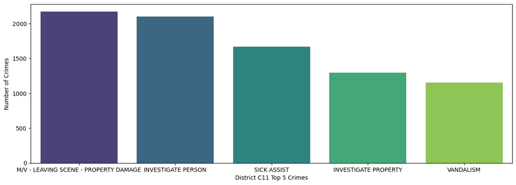

```python
plt.figure(figsize=(15,5))

dist = sns.barplot(data=tfC11, y='count',x="offense_description", orient='v', palette='viridis')

dist.set_xlabel( "District C11 Top 5 Crimes")
dist.set_ylabel( "Number of Crimes")
```

```python
tfA1=crime1.groupBy("district",'offense_description').agg(F.count('*').alias('count')).where(F.col("district") == "A1").orderBy(F.desc('count')).limit(5)
tfA1.show()
```

```
+--------+--------------------+-----+
|district| offense_description|count|
+--------+--------------------+-----+
|      A1|         SICK ASSIST| 2025|
|      A1|  INVESTIGATE PERSON| 1845|
|      A1|    ASSAULT - SIMPLE| 1465|
|      A1| LARCENY SHOPLIFTING| 1432|
|      A1|INVESTIGATE PROPERTY| 1093|
+--------+--------------------+-----+
```

```python
tfA1=tfA1.toPandas()
tfA1.head()
```

|  | district | offense_description | count |
| --- | --- | --- | --- |
| 0 | A1 | SICK ASSIST | 2025 |
| 1 | A1 | INVESTIGATE PERSON | 1845 |
| 2 | A1 | ASSAULT - SIMPLE | 1465 |
| 3 | A1 | LARCENY SHOPLIFTING | 1432 |
| 4 | A1 | INVESTIGATE PROPERTY | 1093 |

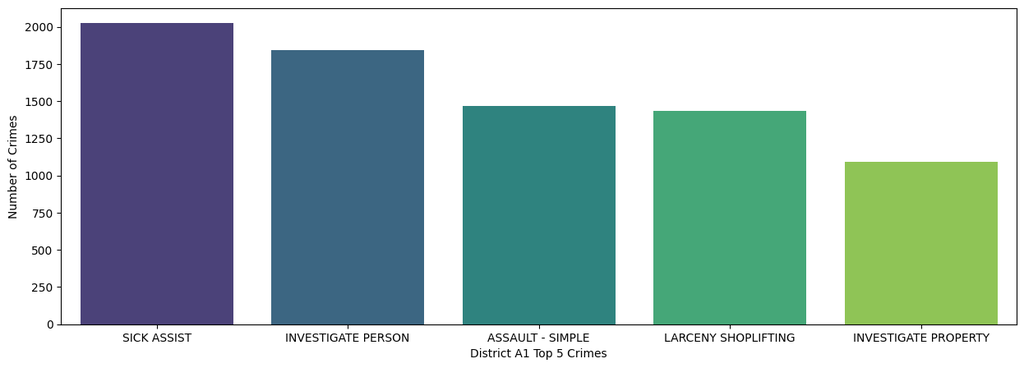

```python
plt.figure(figsize=(15,5))

dist = sns.barplot(data=tfA1, y='count',x="offense_description", orient='v', palette='viridis')

dist.set_xlabel( "District A1 Top 5 Crimes")
dist.set_ylabel( "Number of Crimes")
```

```python
tfB3=crime1.groupBy("district",'offense_description').agg(F.count('*').alias('count')).where(F.col("district") == "B3").orderBy(F.desc('count')).limit(5)
tfB3.show()
```

```
+--------+--------------------+-----+
|district| offense_description|count|
+--------+--------------------+-----+
|      B3|  INVESTIGATE PERSON| 2670|
|      B3|         SICK ASSIST| 1424|
|      B3|M/V - LEAVING SCE...| 1348|
|      B3|INVESTIGATE PROPERTY| 1201|
|      B3|           VANDALISM|  953|
+--------+--------------------+-----+
```

```python
tfB3=tfB3.toPandas()
tfB3.head()
```

|  | district | offense_description | count |
| --- | --- | --- | --- |
| 0 | B3 | INVESTIGATE PERSON | 2670 |
| 1 | B3 | SICK ASSIST | 1424 |
| 2 | B3 | M/V - LEAVING SCENE - PROPERTY DAMAGE | 1348 |
| 3 | B3 | INVESTIGATE PROPERTY | 1201 |
| 4 | B3 | VANDALISM | 953 |

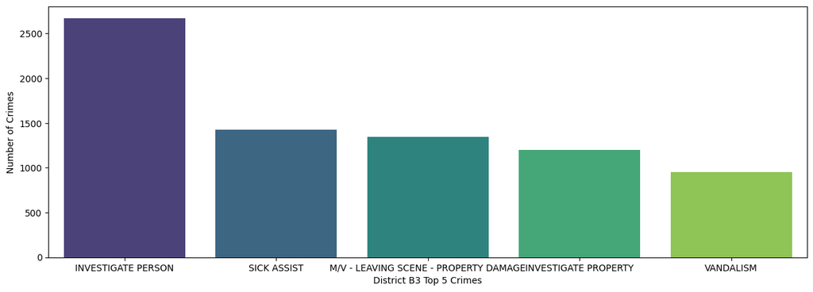

```python
plt.figure(figsize=(15,5))

dist = sns.barplot(data=tfB3, y='count',x="offense_description", orient='v', palette='viridis')

dist.set_xlabel( "District B3 Top 5 Crimes")
dist.set_ylabel( "Number of Crimes")
```

# My Own Questions

- 1. What is the day of the week that is the highest for stealing from a building is the highest crime?
- 1. What street has the highest amount of crime?
- 1. What is the street with the highest amount of Shoplifting?
- 1. What district has the highest number of vandalisms?
- 1. What month is the highest for towed vehicles?

## 1. What is the day of the week that is the highest for stealing from a building is the highest crime?

```python
building=crime1.groupBy("day_of_week",'offense_description').agg(F.count('*').alias('count')).where(F.col("offense_description") == "LARCENY THEFT FROM BUILDING").orderBy(F.desc('count'))
```

```python
building= building.toPandas()
building.head()
```

|  | day_of_week | offense_description | count |
| --- | --- | --- | --- |
| 0 | Friday | LARCENY THEFT FROM BUILDING | 743 |
| 1 | Tuesday | LARCENY THEFT FROM BUILDING | 678 |
| 2 | Wednesday | LARCENY THEFT FROM BUILDING | 664 |
| 3 | Thursday | LARCENY THEFT FROM BUILDING | 657 |
| 4 | Monday | LARCENY THEFT FROM BUILDING | 645 |

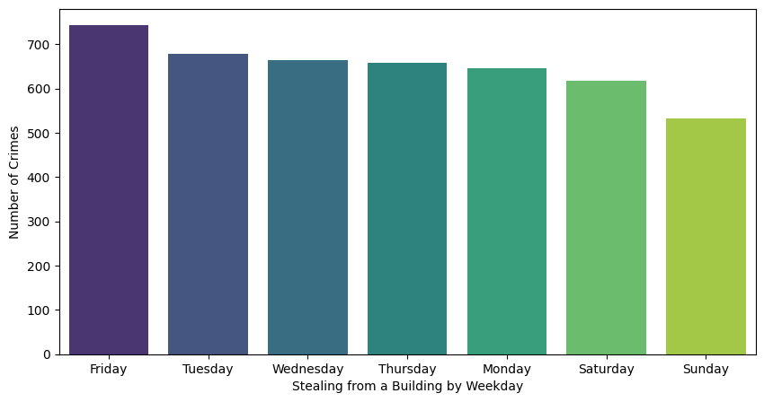

```python
plt.figure(figsize=(10,5))

building = sns.barplot(data=building, y='count',x='day_of_week',orient='v', palette='viridis')

building.set_xlabel( "Stealing from a Building by Weekday")
building.set_ylabel( "Number of Crimes")
```

## The day with the highest number of crimes labeled Stealing from a building is Friday

## 2. What street has the highest amount of crime?

```python
street=crime1.groupBy('street').agg(F.count('*').alias('count')).orderBy(F.desc('count')).limit(5)
street.show()
```

```
+-------------+-----+
|       street|count|
+-------------+-----+
|WASHINGTON ST|15551|
|    GIBSON ST| 6275|
|BLUE HILL AVE| 6247|
| HARRISON AVE| 6048|
|    CENTRE ST| 4441|
+-------------+-----+
```

```python
street= street.toPandas()
street.head()
```

|  | street | count |
| --- | --- | --- |
| 0 | WASHINGTON ST | 15551 |
| 1 | GIBSON ST | 6275 |
| 2 | BLUE HILL AVE | 6247 |
| 3 | HARRISON AVE | 6048 |
| 4 | CENTRE ST | 4441 |

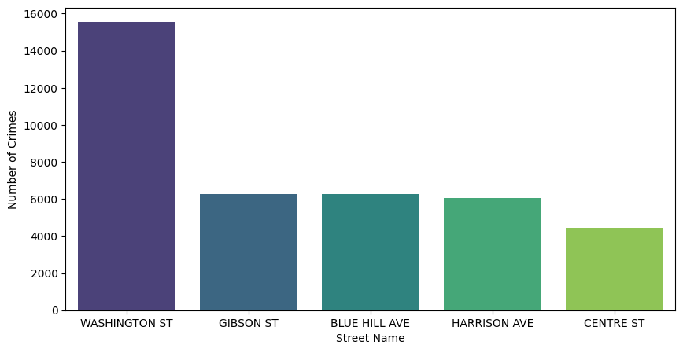

```python
plt.figure(figsize=(10,5))

street = sns.barplot(data=street, y='count',x='street',orient='v', palette='viridis')

street.set_xlabel( "Street Name")
street.set_ylabel( "Number of Crimes")
```

### The street with the highest number of crimes in Boston is Washington St

## 3. What is the street with the highest amount of Shoplifting?

```python
shop=crime1.groupBy("street",'offense_description').agg(F.count('*').alias('count')).where(F.col("offense_description") == "LARCENY SHOPLIFTING").orderBy(F.desc('count')).limit(10)
shop.show()
```

```
+-----------------+-------------------+-----+
|           street|offense_description|count|
+-----------------+-------------------+-----+
|    WASHINGTON ST|LARCENY SHOPLIFTING| 1191|
|      BOYLSTON ST|LARCENY SHOPLIFTING|  828|
|       NEWBURY ST|LARCENY SHOPLIFTING|  484|
|   HUNTINGTON AVE|LARCENY SHOPLIFTING|  445|
|    BLUE HILL AVE|LARCENY SHOPLIFTING|  229|
|MASSACHUSETTS AVE|LARCENY SHOPLIFTING|  169|
|     COLUMBUS AVE|LARCENY SHOPLIFTING|  142|
|        BORDER ST|LARCENY SHOPLIFTING|  134|
|        CENTRE ST|LARCENY SHOPLIFTING|  130|
|   DORCHESTER AVE|LARCENY SHOPLIFTING|  116|
+-----------------+-------------------+-----+
```

```python
shop= shop.toPandas()
shop.head()
```

|  | street | offense_description | count |
| --- | --- | --- | --- |
| 0 | WASHINGTON ST | LARCENY SHOPLIFTING | 1191 |
| 1 | BOYLSTON ST | LARCENY SHOPLIFTING | 828 |
| 2 | NEWBURY ST | LARCENY SHOPLIFTING | 484 |
| 3 | HUNTINGTON AVE | LARCENY SHOPLIFTING | 445 |
| 4 | BLUE HILL AVE | LARCENY SHOPLIFTING | 229 |

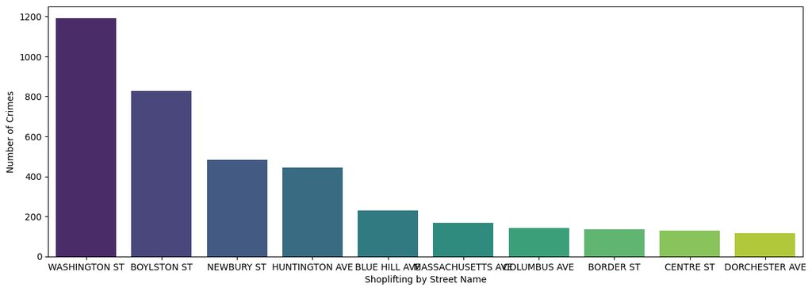

```python
plt.figure(figsize=(15,5))

shop = sns.barplot(data=shop, y='count',x='street',orient='v', palette='viridis')

shop.set_xlabel( "Shoplifting by Street Name")
shop.set_ylabel( "Number of Crimes")
```

### The street with the highest amount of shoplifting crimes is Washington St followed by Boylston St and Newbury Street

## 4. What district has the highest number of vandalisms?

```python
vand=crime1.groupBy("district",'offense_description').agg(F.count('*').alias('count')).where(F.col("offense_description") == "VANDALISM").orderBy(F.desc('count')).limit(5)
vand.show()
```

```
+--------+-------------------+-----+
|district|offense_description|count|
+--------+-------------------+-----+
|      B2|          VANDALISM| 1191|
|     C11|          VANDALISM| 1151|
|      B3|          VANDALISM|  953|
|      D4|          VANDALISM|  858|
|      C6|          VANDALISM|  806|
+--------+-------------------+-----+
```

```python
vand= vand.toPandas()
vand.head()
```

|  | district | offense_description | count |
| --- | --- | --- | --- |
| 0 | B2 | VANDALISM | 1191 |
| 1 | C11 | VANDALISM | 1151 |
| 2 | B3 | VANDALISM | 953 |
| 3 | D4 | VANDALISM | 858 |
| 4 | C6 | VANDALISM | 806 |

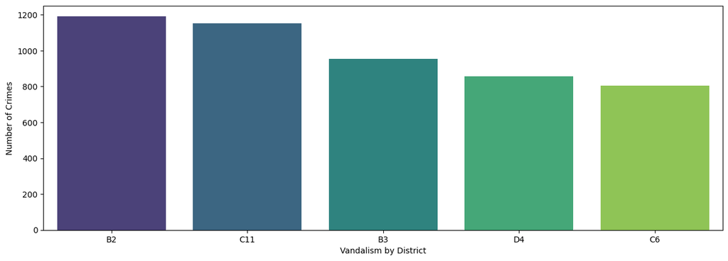

```python
plt.figure(figsize=(15,5))

vand = sns.barplot(data=vand, y='count',x='district',orient='v', palette='viridis')

vand.set_xlabel( "Vandalism by District")
vand.set_ylabel( "Number of Crimes")
```

### The district with the highest amount of Vandalism crimes is B2 followed closely by C11

## 5. What month is the highest for towed vehicles?

```python
tow=crime1.groupBy("month",'offense_description').agg(F.count('*').alias('count')).where(F.col("offense_description") == "TOWED MOTOR VEHICLE").orderBy(F.desc('count'))
tow.show()
```

```
+-----+-------------------+-----+
|month|offense_description|count|
+-----+-------------------+-----+
|    8|TOWED MOTOR VEHICLE|  975|
|    6|TOWED MOTOR VEHICLE|  853|
|    5|TOWED MOTOR VEHICLE|  837|
|    3|TOWED MOTOR VEHICLE|  789|
|    7|TOWED MOTOR VEHICLE|  768|
|    1|TOWED MOTOR VEHICLE|  745|
|    4|TOWED MOTOR VEHICLE|  716|
|    2|TOWED MOTOR VEHICLE|  701|
|    9|TOWED MOTOR VEHICLE|  628|
|   10|TOWED MOTOR VEHICLE|  551|
|   11|TOWED MOTOR VEHICLE|  481|
|   12|TOWED MOTOR VEHICLE|  474|
+-----+-------------------+-----+
```

```python
tow= tow.toPandas()
tow.head()
```

|  | month | offense_description | count |
| --- | --- | --- | --- |
| 0 | 8 | TOWED MOTOR VEHICLE | 975 |
| 1 | 6 | TOWED MOTOR VEHICLE | 853 |
| 2 | 5 | TOWED MOTOR VEHICLE | 837 |
| 3 | 3 | TOWED MOTOR VEHICLE | 789 |
| 4 | 7 | TOWED MOTOR VEHICLE | 768 |

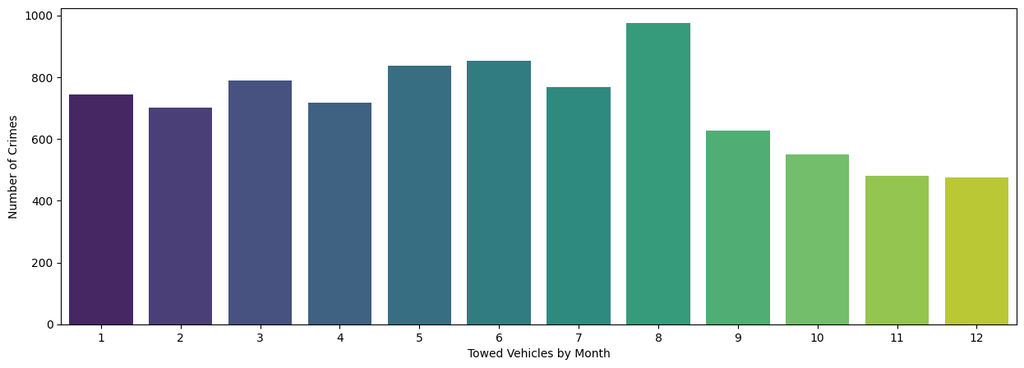

```python
plt.figure(figsize=(15,5))

tow = sns.barplot(data=tow, y='count',x='month',orient='v', palette='viridis')

tow.set_xlabel( "Towed Vehicles by Month")
tow.set_ylabel( "Number of Crimes")
```

### The month with the highest number of towed vehicle crimes is month 8 or August

```python
spark.stop()
```